# Machine Learning For Signal Processing (ENGR-E 511) Homework 5 , Spring 2022

**Name: Anitha Ganapathy**  
**Email: aganapa@iu.edu**

Organizing the imports

```python
!pip install ipympl
```

```python
# Import the necessary libraries

from mpl_toolkits.mplot3d import Axes3D
from google.colab import output
output.enable_custom_widget_manager()

from PIL import Image
import numpy as np
import pandas as pd
import matplotlib.pyplot as plt
# import matplotlib.mlab as mlab
import librosa
import soundfile as sf
from IPython.display import Audio
import cmath, math
import scipy.io  # to read .mat files
import seaborn as sns
from numpy.core.fromnumeric import size
import scipy
from scipy.spatial.distance import pdist, squareform
from scipy import exp
from numpy.linalg import eigh

from google.colab import drive

drive.mount('/content/drive')
```

```python
dirpath = '/content/drive/MyDrive/MLSP_data/'
!ls $dirpath
```

```
 concentric.mat  'HW_1 data'  'HW_3 data'      pts.txt	    trn.wav   x_nmf.wav
 eeg.mat	 'HW_2 data'   MDS_pdist.mat   recordings   trs.wav
```

## **P1: Kernel PCA**

```python
file = 'concentric.mat'
con_mat = scipy.io.loadmat(dirpath+file)
```

```python
print(con_mat.keys())
```

```
dict_keys(['__header__', '__version__', '__globals__', 'X'])
```

```python
X = con_mat.get('X')
X.shape
```

```
(2, 152)
```

```python
# X= np.transpose(X)
# X.shape
```

**You know, the first 51 samples are for the inner circle, so their label will be 0, while for the other outer ring samples, I’d label them with 1**

```python
label_0 = np.repeat(0,51)
label_1 = np.repeat(1,101)
Y = np.concatenate((label_0, label_1), axis=0)
Y.shape
```

```
(152,)
```

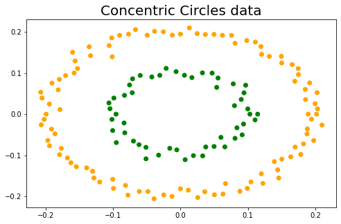

```python
colors = ['orange' if label==1 else 'green' for label in Y]

plt.figure(figsize=(8,5))
plt.scatter(X[0,:], X[1,:], c = colors)
plt.title("Concentric Circles data", fontsize=20)
plt.show()
```

```python
X.shape, Y.shape
```

```
((2, 152), (152,))
```

### *Gaussian radius basis function (RBF) kernel*

RBF kernel that is used to perform nonlinear dimensionality reduction via BF kernel principal component analysis (kPCA).

**Implementing the RBF kernel PCA step-by-step**

https://sebastianraschka.com/Articles/2014_kernel_pca.html

In order to implement the RBF kernel PCA we just need to consider the following two steps.

1. Computation of the kernel (similarity) matrix. In this first step, we need to calculate

$$ \kappa\left(\mathbf{x}_{\mathbf{i}}, \mathbf{x}_{\mathbf{j}}\right)=\exp \left(-\gamma\left\|\mathbf{x}_{\mathbf{i}}-\mathbf{x}_{\mathbf{j}}\right\|_{2}^{2}\right) $$

for every pair of points. E.g., if we have a dataset of 100 samples, this step would result in a symmetric 100x100 kernel matrix.

1. Eigendecomposition of the kernel matrix. Since it is not guaranteed that the kernel matrix is centered, we can apply the following equation to do so:

$$ K^{\prime}=K-\mathbf{1}_{\mathbf{N}} K-K \mathbf{1}_{\mathbf{N}}+\mathbf{1}_{\mathbf{N}} K \mathbf{1}_{\mathbf{N}} $$

where $\mathbf{1}_{\mathbf{N}}$ is (like the kernel matrix) a $N \times N$ matrix with all values equal to $\frac{1}{N}$. [3]

Now, we have to obtain the eigenvectors of the centered kernel matrix that correspond to the largest eigenvalues. Those eigenvectors are the data points already projected onto the respective principal components.

Do kernel PCA on this data set to transform them into a new 3-dimensional feature space, i.e. $$ \boldsymbol{X} \in \mathbb{R}^{2 \times 152} \Rightarrow \text { Kernel PCA } \Rightarrow Z \in \mathbb{R}^{3 \times 152} $$

https://github.com/JAVI897/Kernel-PCA/blob/master/kernels.py  
https://odsc.medium.com/implementing-a-kernel-principal-component-analysis-in-python-495f04a7f85f

```python
def rbf_kernel_pca(X, gamma, n_components):
    sq_dists = pdist(X,  metric='sqeuclidean')

    mat_sq_dists = squareform(sq_dists)
    K = exp(-gamma * mat_sq_dists)
    print('K shape: ',K.shape)
    N = K.shape[0]
    one_n = np.ones((N,N)) / N
    K = K - one_n.dot(K) - K.dot(one_n) + one_n.dot(K).dot(one_n)
    eigvals, eigvecs = eigh(K)
    print('eigvals, eigvecs  shape : ', eigvals.shape, eigvecs.shape )
    eigvals, eigvecs = eigvals[::-1], eigvecs[:, ::-1]
    print('eigvals, eigvecs  shape : ', eigvals.shape, eigvecs.shape )

    X_pc = np.column_stack([eigvecs[:, i] for i in range(n_components)])
    return X_pc

X_kpca = rbf_kernel_pca(X.T, gamma=450, n_components=3)
```

```
K shape:  (152, 152)
eigvals, eigvecs  shape :  (152,) (152, 152)
eigvals, eigvecs  shape :  (152,) (152, 152)
```

```
<function matplotlib.pyplot.show>
```

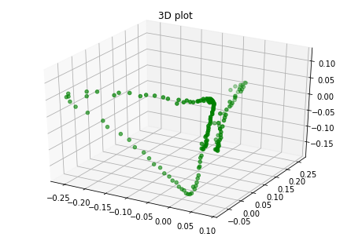

```python
# %matplotlib widget
# creating figure
fig = plt.figure()
ax = Axes3D(fig)

# creating the plot
ax.scatter(X_kpca[:,0], X_kpca[:,1], X_kpca[:,2], color='green')

# setting title and labels
ax.set_title("3D plot")
plt.show
```

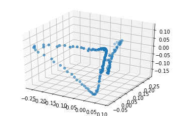

```python
fig = plt.figure()
ax = fig.add_subplot(111, projection = '3d')
ax.scatter(X_kpca[:,0], X_kpca[:,1], X_kpca[:,2], c = None)
plt.show()
```

### Perceptron training for the concentric circles

```python
def activation(x):
    return 1/(1 + np.exp(-x))
```

```
Weights of the perceptron are:  [ -7.20057312 -37.14631995   2.91468795]
Error is:  [49.36756381]
```

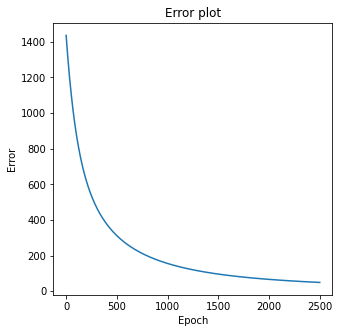

```python
X = X_kpca.T


# Note that you may want to initialize your parameters with some small (uniform or Gaussian) random numbers centered around zero.
W = np.random.uniform(0, 1, size=3).reshape(-1, 1)
error_plot = []
max_epochs = 2500

alpha = 0.01 # learning rate

for epoch in range (max_epochs):
    prediction = activation(np.dot(W.T, X))
    error = np.dot((Y - prediction),(Y - prediction).T)**2
    error_plot.append(error)
    delta_W = np.dot(X,(prediction - Y).T )
    W = W - alpha * delta_W

Y_hat = activation(np.dot(W.T, X))
d = Y-Y_hat
error = np.dot(d,d.T)**2
print('Weights of the perceptron are: ', W.reshape(-1))

print('Error is: ' , error.reshape(-1))

# plotting the epoch vs error

x_data = [i for i in range(max_epochs)]
y_data = np.array(error_plot).reshape(-1)
plt.figure(figsize=(5,5))
plt.plot(x_data, y_data)
plt.title('Error plot')
plt.xlabel("Epoch")
plt.ylabel("Error")
plt.show()
```

## **P2: Neural Networks**

- https://github.com/haalberto/Neural-Network-Classifier/blob/master/NeuralNet_1L.py
- https://eisenjulian.github.io/deep-learning-in-100-lines/index.html
- https://machinelearningmastery.com/implement-backpropagation-algorithm-scratch-python/
- https://pgg1610.github.io/blog_fastpages/python/pytorch/machine-learning/2021/02/05/NN_classification_from_scratch.html
- https://scipython.com/blog/a-shallow-neural-network-for-simple-nonlinear-classification/

```python
file = 'concentric.mat'
con_mat = scipy.io.loadmat(dirpath+file)
```

```python
X = con_mat.get('X')
X.shape
```

```
(2, 152)
```

**You know, the first 51 samples are for the inner circle, so their label will be 0, while for the other outer ring samples, I’d label them with 1**

```python
label_0 = np.repeat(0,51)
label_1 = np.repeat(1,101)
Y = np.concatenate((label_0, label_1), axis=0)
Y.shape
```

```
(152,)
```

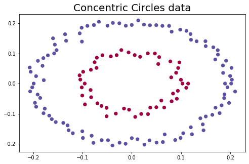

```python
colors = ['orange' if label==1 else 'green' for label in Y]

plt.figure(figsize=(8,5))
plt.scatter(X[0,:], X[1,:], c=Y.ravel(), s=40, cmap=plt.cm.Spectral)
plt.title("Concentric Circles data", fontsize=20)
plt.show()
```

```python
shape_X = X.shape
shape_Y = Y.shape

print ('The shape of X is: ' + str(shape_X))
print ('The shape of Y is: ' + str(shape_Y))
```

```
The shape of X is: (2, 152)
The shape of Y is: (152,)
```

```python
Y = Y.reshape(1, -1)
```

```python
Y.shape
```

```
(1, 152)
```

### Define three variables:

- n_x: the size of the input layer
- n_h: the size of the hidden layer (set this to 1)
- n_y: the size of the output layer

```python
def layer_sizes(X, Y, n_h=1):
  n_x = X.shape[0] # size of input layer
  n_h = n_h        # he size of the hidden layer (set this to 1)
  n_y = Y.reshape(-1,1).T.shape[0] # size of output layer

  return (n_x, n_h, n_y)
```

```python
(n_x, n_h, n_y) = layer_sizes(X, Y)
print("The size of the input layer is: n_x = " ,n_x)
print("The size of the hidden layer is: n_h = " ,n_h)
print("The size of the output layer is: n_y = " ,n_y)
```

```
The size of the input layer is: n_x =  2
The size of the hidden layer is: n_h =  1
The size of the output layer is: n_y =  1
```

```python
def initialize_parameters(n_x, n_h, n_y):
  np.random.seed(99)

  W1 = np.random.randn(n_h, n_x) * 0.01
  b1 = np.zeros((n_h,1))

  W2 = np.random.randn(n_y, n_h) * 0.01
  b2 = np.zeros((n_y,1))

  parameters = {"W1": W1,
              "b1": b1,
              "W2": W2,
              "b2": b2}

  return parameters
```

```python
def sigmoid(x):
  return 1/(1 + np.exp(-x))
```

```python
def forward_propagation(X, parameters):
  # Retrieve each parameter from the dictionary "parameters"
  W1 = parameters['W1']
  b1 = parameters['b1']
  W2 = parameters['W2']
  b2 = parameters['b2']

  # Implement Forward Propagation
  Z1 = np.dot(W1,X) + b1
  A1 = activation(Z1)

  Z2 = np.dot(W2,A1) + b2
  A2 = activation(Z2)

  cache = {"Z1": Z1,
            "A1": A1,
            "Z2": Z2,
            "A2": A2}
  # print(cache)
  return A2, cache
```

```python
def compute_loss(A2, Y):
  m = Y.shape[1] # number of example

  logprobs = np.dot(Y,np.log(A2).T) + np.dot((1-Y),np.log((1-A2)).T)
  loss = -logprobs/m
  loss = float(np.squeeze(loss))

  return loss
```

```python
def backward_propagation(parameters, cache, X, Y):
  m = X.shape[1]

  # First, retrieve W1 and W2 from the dictionary "parameters".
  W1 = parameters['W1']
  W2 = parameters['W2']

  # Retrieve also A1 and A2 from dictionary "cache".
  A1 = cache['A1']
  A2 = cache['A2']

  # Backward propagation: calculate dW1, db1, dW2, db2.
  dZ2 = A2 - Y
  dW2 = (1/m) * np.dot(dZ2,A1.T)
  db2 = (1/m) * np.sum(dZ2,axis=1, keepdims=True)
  dZ1 = np.dot(W2.T, dZ2) * (1 - np.power(A1, 2))
  dW1 = (1/m) * np.dot(dZ1, X.T)
  db1 = (1/m) * np.sum(dZ1, axis=1, keepdims=True)

  grads = {"dW1": dW1,
            "db1": db1,
            "dW2": dW2,
            "db2": db2}

  return grads
```

```python
def update_parameters(parameters, grads, lr):
    # Retrieve each parameter from the dictionary "parameters"
    W1 = parameters['W1']
    b1 = parameters['b1']
    W2 = parameters['W2']
    b2 = parameters['b2']

    # Retrieve each gradient from the dictionary "grads"
    dW1 = grads['dW1']
    db1 = grads['db1']
    dW2 = grads['dW2']
    db2 = grads['db2']

    # Update rule for each parameter
    W1 = W1 - lr*dW1
    b1 = b1 - lr*db1
    W2 = W2 - lr*dW2
    b2 = b2 - lr*db2

    parameters = {"W1": W1,
                  "b1": b1,
                  "W2": W2,
                  "b2": b2}

    return parameters
```

```python
def nn_model(X, Y, n_h, num_iterations = 10000, print_loss=False):
    lr = 0.0005
    np.random.seed(42)
    n_x, n_h, n_y = layer_sizes(X, Y, n_h=n_h)
    loss_calc = []
    # loss = 0
    # Initialize parameters
    parameters = initialize_parameters(n_x, n_h, n_y)

    # Loop (gradient descent)
    for i in range(0, num_iterations):

        # Forward propagation. Inputs: "X, parameters". Outputs: "A2, cache".
        A2, cache = forward_propagation(X, parameters)

        # loss function. Inputs: "A2, Y, parameters". Outputs: "loss".
        loss = compute_loss(A2, Y)
        loss_calc.append(loss)
        # Backpropagation. Inputs: "parameters, cache, X, Y". Outputs: "grads".
        grads = backward_propagation(parameters, cache, X, Y)

        # Gradient descent parameter update. Inputs: "parameters, grads". Outputs: "parameters".
        parameters = update_parameters(parameters, grads, lr)

        # Print the loss every 1000 iterations
        if print_loss and i % 1000 == 0:
            print (f"Loss after iteration {i}: {loss}")
    print ("\nFinal Loss after training: ", loss)
    return parameters, loss_calc
```

```python
def predict(parameters, X):

    # Computes probabilities using forward propagation, and classifies to 0/1 using 0.5 as the threshold.
    A2, cache = forward_propagation(X, parameters)
    threshold = 0.5
    predictions = (A2 > threshold)

    return predictions
```

```python
parameters, loss_calc  = nn_model(X, Y, n_h = 1, num_iterations = 30000, print_loss=True)
```

```
Loss after iteration 0: 0.6929144840135212
Loss after iteration 1000: 0.6784523542705031
Loss after iteration 2000: 0.6678568010335262
Loss after iteration 3000: 0.6600799445650275
Loss after iteration 4000: 0.6543601802900045
Loss after iteration 5000: 0.6501444319153155
Loss after iteration 6000: 0.6470307436810452
Loss after iteration 7000: 0.6447264774060498
Loss after iteration 8000: 0.6430180944153089
Loss after iteration 9000: 0.6417493796462964
Loss after iteration 10000: 0.6408057563330993
Loss after iteration 11000: 0.6401029739626403
Loss after iteration 12000: 0.6395789320521784
Loss after iteration 13000: 0.6391877540554667
Loss after iteration 14000: 0.6388954791172915
Loss after iteration 15000: 0.6386769202947579
Loss after iteration 16000: 0.638513366470747
Loss after iteration 17000: 0.638390896534369
Loss after iteration 18000: 0.6382991393626162
Loss after iteration 19000: 0.6382303594424784
Loss after iteration 20000: 0.638178781085882
Loss after iteration 21000: 0.6381400879548429
Loss after iteration 22000: 0.6381110517350362
Loss after iteration 23000: 0.6380892561772232
Loss after iteration 24000: 0.6380728917130115
Loss after iteration 25000: 0.6380606023979363
Loss after iteration 26000: 0.6380513717194675
Loss after iteration 27000: 0.6380444373152961
Loss after iteration 28000: 0.6380392272261993
Loss after iteration 29000: 0.6380353122087342

Final Loss after training:  0.638032372579897
```

### Accuracy

```python
predictions = predict(parameters, X)
print(Y.size)
print (f'Accuracy: {float((np.dot(Y,predictions.T) + np.dot(1-Y,1-predictions.T)) /Y.size)*100} %')
```

```
152
Accuracy: 66.44736842105263 %
```

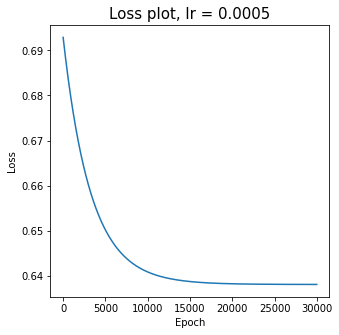

```python
x_data = [i for i in range(len(loss_calc))]
y_data = np.array(loss_calc).reshape(-1)
plt.figure(figsize=(5,5))
plt.plot(x_data, y_data)
plt.title('Loss plot, lr = 0.0005', fontsize=15)
plt.xlabel("Epoch")
plt.ylabel("Loss")
plt.show()
```

## **P3: Spoken MNIST**

```python
!pip install hmmlearn
```

```python
from hmmlearn.hmm import GMMHMM
```

```python
# !ls $dirpath'recordings'
```

```python
file, sr = librosa.load(dirpath+'recordings/'+'0_jackson_0.wav', sr = None)
Audio(file, rate = sr)
```

[interactive chart not shown]

```python
file, sr = librosa.load(dirpath+'recordings/'+'0_jackson_1.wav', sr = None)
Audio(file, rate = sr)
```

[interactive chart not shown]

```python
file, sr = librosa.load(dirpath+'recordings/'+'1_jackson_0.wav', sr = None)
Audio(file, rate = sr)
```

[interactive chart not shown]

```python
file, sr = librosa.load(dirpath+'recordings/'+'1_jackson_1.wav', sr = None)
Audio(file, rate = sr)
```

[interactive chart not shown]

```python
y, sr = librosa.load(dirpath+'recordings/'+'1_jackson_45.wav', sr = None)
print(y.shape)
y_mfcc = librosa.feature.mfcc(y=y, sr=sr)
print(y_mfcc.shape)
```

```
(4809,)
(20, 10)
```

```python
sr
```

```
8000
```

First, for digit class $C$, let's convert each of the 45 utterances into an MFCC spectrogram. You will use a toolbox for this: librosa.feature.mfcc. As a result, you produce $\boldsymbol{X}_{i}^{(C)} \in$ $\mathbb{R}^{20 \times T_{i}^{(C)}}$, where $T_{i}^{(C)}$ is the number of MFCC vectors of the $i$-th utterance in the digit class $C$. Store both the MFCC matrix $\boldsymbol{X}_{i}^{(C)}$ and length information $T_{i}^{(C)}$. Repeat this for all 45 utterances.

```python
def audio_to_mfcc(file_name):
  y, sr = librosa.load(file_name , sr = None)
  mfcc_output =  librosa.feature.mfcc(y=y, sr=sr)
  # print("mfcc_output shape : ", mfcc_output.shape)
  return mfcc_output
```

### Preparing the X_train and fitting 10 models

```python
sampling_rate = 8000
model_GMMHMM = [None]*10
x_train = []
y_train = []
x_test = []
y_test = []


for i in range(10): # label digits 0 to 9
  x_train = []
  y_train = []

  for j in range(50): # 50 speech occurrances of jackson
    file_path = dirpath+'recordings/'+str(i)+'_jackson_'+str(j)+'.wav'
    if j <45:
      x_train.append(audio_to_mfcc(file_path))
      y_train.append(i)

  print("\n------------------------------------------------------------------------------")
  print(f"Data for label {i}")
  print("Samples in x_train : ", len(x_train))
  print("Labels len in y_train : ", len(y_train))

  train_data = x_train[0]
  n_train_components = []
  n_train_components.append(x_train[0].shape[1])


  for n in range(1, len(x_train)):
    train_data = np.append(train_data, x_train[n], axis = 1)
    n_train_components.append(x_train[n].shape[1])

  print("Train data size : ", train_data.shape)
  print("length of n_train_components : ", len(n_train_components))
  print("Sample of n_train_components : ", n_train_components[0])
  model_GMMHMM[i] = GMMHMM(n_components=10,n_iter=10, tol=0.001, verbose=True, random_state=42)
  # model_GMMHMM[i].fit(train_data.T)
  model_GMMHMM[i].fit(train_data.T, lengths =n_train_components)
```

```
------------------------------------------------------------------------------
Data for label 0
Samples in x_train :  45
Labels len in y_train :  45
Train data size :  (20, 455)
length of n_train_components :  45
Sample of n_train_components :  11
```

```
         1      -34518.8117             +nan
         2      -31693.5754       +2825.2363
         3      -31502.1960        +191.3794
         4      -31473.6495         +28.5466
         5      -31456.9124         +16.7371
         6      -31443.8822         +13.0301
         7      -31433.9986          +9.8836
         8      -31427.9714          +6.0271
         9      -31422.4783          +5.4932
        10      -31409.4782         +13.0001
```

```
------------------------------------------------------------------------------
Data for label 1
Samples in x_train :  45
Labels len in y_train :  45
Train data size :  (20, 384)
length of n_train_components :  45
Sample of n_train_components :  9
```

```
         1      -28988.2004             +nan
         2      -27038.3777       +1949.8227
         3      -26745.1652        +293.2126
         4      -26690.2114         +54.9538
         5      -26669.1008         +21.1105
         6      -26664.8931          +4.2077
         7      -26663.1867          +1.7064
         8      -26656.2405          +6.9463
         9      -26649.3031          +6.9374
        10      -26648.6135          +0.6895
```

```
------------------------------------------------------------------------------
Data for label 2
Samples in x_train :  45
Labels len in y_train :  45
Train data size :  (20, 384)
length of n_train_components :  45
Sample of n_train_components :  8
```

```
         1      -29540.5497             +nan
         2      -27118.0273       +2422.5224
         3      -26975.7701        +142.2572
         4      -26963.9532         +11.8169
         5      -26960.3652          +3.5880
         6      -26957.4516          +2.9136
         7      -26956.6328          +0.8188
         8      -26955.6218          +1.0111
         9      -26953.5057          +2.1161
        10      -26952.2292          +1.2766
```

```
------------------------------------------------------------------------------
Data for label 3
Samples in x_train :  45
Labels len in y_train :  45
Train data size :  (20, 358)
length of n_train_components :  45
Sample of n_train_components :  8
```

```
         1      -26166.5877             +nan
         2      -24299.1556       +1867.4322
         3      -24173.7575        +125.3981
         4      -24126.6579         +47.0995
         5      -24084.6995         +41.9584
         6      -24039.1899         +45.5096
         7      -24008.6744         +30.5155
         8      -24002.4724          +6.2020
         9      -23998.2606          +4.2118
        10      -23996.6628          +1.5978
```

```
------------------------------------------------------------------------------
Data for label 4
Samples in x_train :  45
Labels len in y_train :  45
Train data size :  (20, 320)
length of n_train_components :  45
Sample of n_train_components :  8
```

```
         1      -24008.1599             +nan
         2      -22021.5624       +1986.5975
         3      -21920.6930        +100.8694
         4      -21907.9543         +12.7387
         5      -21897.3829         +10.5714
         6      -21895.0785          +2.3044
         7      -21893.1389          +1.9396
         8      -21892.3773          +0.7616
         9      -21892.1091          +0.2682
        10      -21891.9526          +0.1565
```

```
------------------------------------------------------------------------------
Data for label 5
Samples in x_train :  45
Labels len in y_train :  45
Train data size :  (20, 311)
length of n_train_components :  45
Sample of n_train_components :  7
```

```
         1      -22453.2223             +nan
         2      -20996.8129       +1456.4094
         3      -20873.3042        +123.5087
         4      -20844.8418         +28.4625
         5      -20826.2711         +18.5706
         6      -20812.4018         +13.8694
         7      -20805.7956          +6.6062
         8      -20804.7067          +1.0889
         9      -20804.1101          +0.5965
        10      -20803.4789          +0.6312
```

```
------------------------------------------------------------------------------
Data for label 6
Samples in x_train :  45
Labels len in y_train :  45
Train data size :  (20, 523)
length of n_train_components :  45
Sample of n_train_components :  13
```

```
         1      -37729.9554             +nan
         2      -34611.1116       +3118.8438
         3      -34269.9194        +341.1922
         4      -34184.0538         +85.8657
         5      -34126.2705         +57.7833
         6      -34096.2160         +30.0545
         7      -34083.6542         +12.5618
         8      -34068.4417         +15.2125
         9      -34063.8674          +4.5743
        10      -34062.6489          +1.2185
```

```
------------------------------------------------------------------------------
Data for label 7
Samples in x_train :  45
Labels len in y_train :  45
Train data size :  (20, 344)
length of n_train_components :  45
Sample of n_train_components :  7
```

```
         1      -24628.3327             +nan
         2      -23051.2721       +1577.0606
         3      -22763.7208        +287.5513
         4      -22665.1357         +98.5851
         5      -22614.2615         +50.8741
         6      -22601.2266         +13.0349
         7      -22594.8875          +6.3392
         8      -22583.9836         +10.9038
         9      -22578.4700          +5.5136
        10      -22570.0715          +8.3985
```

```
------------------------------------------------------------------------------
Data for label 8
Samples in x_train :  45
Labels len in y_train :  45
Train data size :  (20, 312)
length of n_train_components :  45
Sample of n_train_components :  6
```

```
         1      -22855.2412             +nan
         2      -21241.1732       +1614.0680
         3      -21074.4819        +166.6914
         4      -21051.1658         +23.3160
         5      -21036.8180         +14.3478
         6      -21023.4923         +13.3257
         7      -21003.9536         +19.5387
         8      -20982.8927         +21.0608
         9      -20980.2921          +2.6006
        10      -20977.6885          +2.6037
```

```
------------------------------------------------------------------------------
Data for label 9
Samples in x_train :  45
Labels len in y_train :  45
Train data size :  (20, 436)
length of n_train_components :  45
Sample of n_train_components :  10
```

```
         1      -32019.7917             +nan
         2      -29846.0845       +2173.7072
         3      -29596.7820        +249.3025
         4      -29503.7177         +93.0643
         5      -29448.1154         +55.6023
         6      -29423.5435         +24.5718
         7      -29392.0564         +31.4871
         8      -29353.6109         +38.4456
         9      -29325.0050         +28.6059
        10      -29299.4149         +25.5901
```

```python
print("Number of trained GMMHMM models : ",len(model_GMMHMM))
```

```
Number of trained GMMHMM models :  10
```

### Preparing the X_test and predicting the scores of 10 models

```python
x_test = [None]*50
y_test = [None]*50
count = 0
for i in range(10): # label digits 0 to 9
  for j in range(45,50): # 50 speech occurrances of jackson
    file_path = dirpath+'recordings/'+str(i)+'_jackson_'+str(j)+'.wav'
    x_test[count] = audio_to_mfcc(file_path)
    y_test[count]=i
    count+=1

print(len(x_test))
print(len(y_test))
```

```
50
50
```

```python
len(model_GMMHMM)
```

```
10
```

```python
y_pred=[]
prediction_df = pd.DataFrame()
idx= 0
for i in range(len(x_test)):
  predict_score=[]
  for num in range(len(model_GMMHMM)):
    predict_score.append(model_GMMHMM[num].score(x_test[i].T, lengths = x_test[i].shape[1]))
  prediction_df[idx]= predict_score
  idx+=1
  # y_pred.append(np.argmax(predict_score))
```

### **The prediction score**

```python
prediction_df
```

|  | 0 | 1 | 2 | 3 | 4 | 5 | 6 | 7 | 8 | 9 | ... | 40 | 41 | 42 | 43 | 44 | 45 | 46 | 47 | 48 | 49 |
| --- | --- | --- | --- | --- | --- | --- | --- | --- | --- | --- | --- | --- | --- | --- | --- | --- | --- | --- | --- | --- | --- |
| 0 | -852.409129 | -864.203970 | -853.227347 | -800.235896 | -1082.737532 | -1212.606967 | -1147.747938 | -1235.513113 | -1199.772149 | -878.303190 | ... | -811.282632 | -809.189074 | -780.475248 | -804.547690 | -897.849429 | -1021.089817 | -1221.083696 | -1108.754294 | -1145.037486 | -1293.234693 |
| 1 | -1197.467702 | -1212.651198 | -1164.021447 | -1179.380806 | -1401.223188 | -764.064618 | -655.228841 | -698.976038 | -748.076395 | -631.207715 | ... | -789.768729 | -796.278840 | -754.360712 | -783.685334 | -868.045681 | -770.067047 | -1013.609581 | -915.004708 | -928.936705 | -1037.200009 |
| 2 | -1281.878223 | -1284.101766 | -1220.927055 | -1200.430721 | -1488.455517 | -1242.920909 | -1181.619084 | -1225.962758 | -1200.664215 | -970.080139 | ... | -759.389559 | -758.042815 | -775.638172 | -826.289174 | -901.754819 | -1060.047998 | -1307.070496 | -1210.256061 | -1160.950360 | -1322.938801 |
| 3 | -1598.649428 | -1548.514156 | -1416.513069 | -1492.815889 | -1814.299548 | -1513.489237 | -1311.020106 | -1431.153106 | -1406.924382 | -1107.107296 | ... | -879.428343 | -888.795466 | -823.779855 | -851.742053 | -955.737893 | -1035.930936 | -1346.893264 | -1193.035262 | -1235.443858 | -1406.256219 |
| 4 | -1422.556552 | -1443.194286 | -1421.689933 | -1385.610824 | -1783.260784 | -1463.775461 | -1281.919094 | -1365.203475 | -1404.320474 | -1068.267595 | ... | -1122.683548 | -1162.063917 | -959.781338 | -1050.513883 | -1232.739202 | -1273.389998 | -1680.586045 | -1427.043845 | -1454.060506 | -1689.494753 |
| 5 | -1611.814152 | -1675.920067 | -1632.991727 | -1529.000160 | -1888.014982 | -1263.087109 | -1088.100311 | -1215.071152 | -1196.131913 | -883.982251 | ... | -1179.547681 | -1184.021477 | -927.080801 | -1079.942143 | -1241.399657 | -964.146654 | -1166.653389 | -986.391773 | -995.737108 | -1190.785324 |
| 6 | -1538.003900 | -1561.089581 | -1498.883798 | -1414.148988 | -1773.571340 | -1462.562089 | -1439.385840 | -1594.568957 | -1475.415777 | -1107.705053 | ... | -1121.188122 | -1047.951254 | -994.622832 | -968.112544 | -1087.352471 | -1128.427663 | -1431.274903 | -1260.342380 | -1282.736334 | -1432.009600 |
| 7 | -1658.717711 | -1673.685628 | -1663.363563 | -1506.988828 | -1889.007592 | -1349.606488 | -1207.203795 | -1404.281298 | -1239.343115 | -956.581514 | ... | -1113.908642 | -1050.077882 | -910.919447 | -976.742876 | -1168.782107 | -922.354609 | -1159.022546 | -1022.622366 | -1059.957704 | -1154.826868 |
| 8 | -1595.615147 | -1611.942800 | -1688.161951 | -1502.343664 | -1807.861508 | -1348.544519 | -1197.654066 | -1302.811186 | -1279.647562 | -986.086444 | ... | -486.105582 | -460.720716 | -560.246377 | -489.792012 | -534.182949 | -1044.071699 | -1316.729087 | -1157.875946 | -1136.612289 | -1285.582727 |
| 9 | -1358.648220 | -1326.373302 | -1284.937230 | -1281.115620 | -1582.741346 | -1007.692990 | -881.574123 | -989.549031 | -947.450878 | -708.747107 | ... | -869.224724 | -863.215469 | -784.735592 | -809.014548 | -909.179125 | -620.233769 | -777.890624 | -714.791231 | -725.809628 | -787.695732 |

10 rows × 50 columns

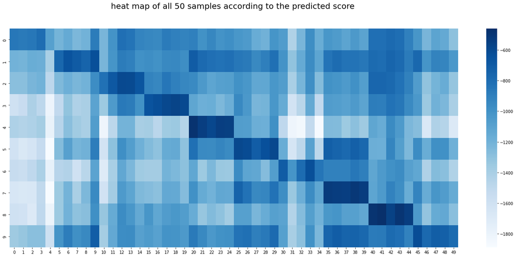

```python
# sns.heatmap(prediction_df)
fig, ax = plt.subplots(figsize=(25,10))
ax = sns.heatmap(prediction_df, annot=False, cmap='Blues')
ax.set_title('heat map of all 50 samples according to the predicted score \n\n', fontsize = 20);
```

```python
y_pred = prediction_df.idxmax(axis=0)
y_pred
```

```
0     0
1     0
2     0
3     0
4     0
5     1
6     1
7     1
8     1
9     1
10    2
11    2
12    2
13    2
14    2
```

[output cut: 36 more lines]

```python
len(y_test), len(y_pred)
```

```
(50, 50)
```

```python
import itertools
from sklearn.metrics import confusion_matrix

cm = confusion_matrix(y_test, y_pred)
cm_df = pd.DataFrame(cm)
cm_df
```

|  | 0 | 1 | 2 | 3 | 4 | 5 | 6 | 7 | 8 | 9 |
| --- | --- | --- | --- | --- | --- | --- | --- | --- | --- | --- |
| 0 | 5 | 0 | 0 | 0 | 0 | 0 | 0 | 0 | 0 | 0 |
| 1 | 0 | 5 | 0 | 0 | 0 | 0 | 0 | 0 | 0 | 0 |
| 2 | 0 | 0 | 5 | 0 | 0 | 0 | 0 | 0 | 0 | 0 |
| 3 | 0 | 0 | 0 | 5 | 0 | 0 | 0 | 0 | 0 | 0 |
| 4 | 0 | 0 | 0 | 0 | 5 | 0 | 0 | 0 | 0 | 0 |
| 5 | 0 | 0 | 0 | 0 | 0 | 5 | 0 | 0 | 0 | 0 |
| 6 | 0 | 0 | 0 | 0 | 0 | 0 | 5 | 0 | 0 | 0 |
| 7 | 0 | 0 | 0 | 0 | 0 | 0 | 0 | 5 | 0 | 0 |
| 8 | 0 | 0 | 0 | 0 | 0 | 0 | 0 | 0 | 5 | 0 |
| 9 | 0 | 0 | 0 | 0 | 0 | 0 | 0 | 0 | 0 | 5 |

### Plotting the CONFUSION MATRIX

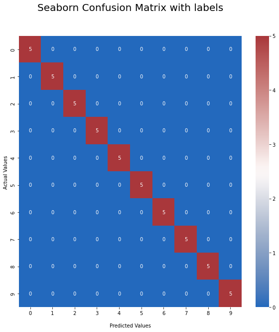

```python
import seaborn as sns
fig, ax = plt.subplots(figsize=(10,10))
ax = sns.heatmap(cm, annot=True, cmap='vlag')

ax.set_title('Seaborn Confusion Matrix with labels\n\n', fontsize = 20);
ax.set_xlabel('\nPredicted Values')
ax.set_ylabel('Actual Values ');

## Ticket labels - List must be in alphabetical order
labels = range(10)
ax.xaxis.set_ticklabels(labels)
ax.yaxis.set_ticklabels(labels)

## Display the visualization of the Confusion Matrix.
plt.show()
```

## **Final: Convert the notebook to HTML**

```python
# %%shell
# jupyter nbconvert --to html /content/AG_MLSP_SP22_HW_5.ipynb
```